# Simple and Multiple Linear Regression

Ian Curtis

2024-03-12

# Welcome

Hey there! This is the second guide in my Modeling Guide with R series. In the previous guide, we performed some preliminary explorations on our dataset and took a look at a few of the variables. We cleaned the dataset up a bit and exported it so we could read it again in later guides.

This page will focus on both simple and multiple linear regression. Although, I cannot cover all of the details and fine use cases of linear regression, we will explore some of the key ideas to focus on when creating and analyzing a linear regression model. We’ll start by importing our data and identifying variables to use in the model then move to creating, interpreting, and testing the model. In both simple and linear regression, we’ll use train/test validation and we’ll also look at several candidate models.

We will be using the same dataset for both the simple and multiple regression cases so let’s get that set up first. As mentioned in the previous, guide, I prefer to use the `tidyverse` family of packages. We’ll also be using the `tidymodels` collection of packages to set up the models and perform our train/test validation.

The code below imports our packages and the data we cleaned in the previous guide. It also splits the data into a train and test set. We will train our models using the training set and will test its performance using the test set. We do this to simulate how the model will perform in the “real world”.

I will be setting the seed for the random generator so we can get the same results each time I start a new R session and split the data. You may or may not wish to do this in your work. I want to make sure we get a roughly equal amount of each store in the split sets so I will take a stratified sample to make the split (`strata = store`).

```r
library(tidyverse)
library(tidymodels)
retail <- read_csv(here::here("data/retail_clean.csv"))
set.seed(52319)
retail_split <- initial_split(retail, prop = .8, strata = store)

train <- training(retail_split)
test <- testing(retail_split)
```

Alright! Now that we have that set, we’ll use the `train` data for all the model creation and will only use the `test` data when we are analyzing our models.

# Simple Linear Regression (SLR)

Although I’ll avoid any complex math throughout this guide, it is important to think about how regression works. The formula for simple linear regression for a population is

$$y = \beta_0 + \beta_1 x_1 + \varepsilon$$

which states that we can represent the relationship between our predictor variable and our response variable as a straight line plus some natural error ($\varepsilon$). The problem is, we don’t know the information about our population (i.e., we don’t have data from all transactions from all stores). Instead, we have a subset of that data (some transactions froms ome stores) and are looking to predict the population values using our sample. As a result, we are creating a model of the form

$$\hat{y} = \hat{\beta_0} + \hat{\beta_1} x_1$$
There is a different here. First, we’ve lost the error term since we are now in prediction mode (there is no error since we know the data we collected). You also now see hats above a few of the values. This indicates that they are estimates of the true values.

## Requirements

When might we want to use SLR? Well, first we need to make sure we have the correct variable types:

- The response variable (the variable we are predicting) must be continuous.
- The predictor variable (the variable we are using to predict) can be either continuous or categorical with two levels.
- We only get one predictor variable and one response variable.

Second, we have to meet certain criteria. See, simple linear regression can be somewhat limiting as it requires us to make certain assumptions about our data and the population we are hoping to model due to the mathematical formulas and matrix algebra used. This is what we should pay attention to:

- The relationship between the predictor variable and the response variable(s) should be linear
- The errors of our predictions should be approximately normally distributed
- Our predictor variable(s) should not be correlated with each other (not a problem in SLR)
- There should be a constant variability in our errors
- Our errors should be independent (we will not focus on this here)

These will be explored later on when we investigate our variables.

## Selecting Variables

Given all of that information, let’s choose the variables we want to use in the model. Suppose we want to have a way to predict the rating of a transaction. The `rating` variable is continuous so it is acceptable to use as a response variable. To try and predict `rating`, we will consider a few candidate models (each with one predictor variable). Let’s start with `total`, and `unit_price` as possible predictors.

At this point, it’s a good idea to write down your predictions about what might happen. This is important as you want to make sure you don’t create a prediction based on your results so you don’t create any bias. At this point, I am thinking that `unit_price` will have the most effect on `rating` since I think that when items cost more, people are more likely to be grumpy and give a lower rating.

Using the formula above, we can create two possible models that we want to use to predict `rating`:

$$\widehat{\text{rating}} = \hat{\beta_0} + \hat{\beta_1} * \text{total}$$

$$\widehat{\text{rating}} = \hat{\beta_0} + \hat{\beta_1} *
\text{unit_price}$$
In each case, we are trying to find the values for $\hat{\beta_0}$ and $\hat{\beta_1}$ using the respective variable.

## Building the Model

Let’s build the model! We will use the `tidymodels` family of packages for this. We first set up the regression engine, then fit the models with our data.

```r
lm_spec <- linear_reg() %>%
  set_mode("regression") %>%
  set_engine("lm")

slr_mod_price <- lm_spec %>%
  fit(rating ~ unit_price, data = train)

slr_mod_total <- lm_spec %>%
  fit(rating ~ total, data = train)
```

Above, I fit two different models, one with `unit_price` and one with `total`. Let’s take a look at the output for both of them.

```r
tidy(slr_mod_price)
```

```
## # A tibble: 2 × 5
##   term        estimate std.error statistic   p.value
##   <chr>          <dbl>     <dbl>     <dbl>     <dbl>
## 1 (Intercept) 6.99       0.142      49.1   2.85e-243
## 2 unit_price  0.000548   0.00230     0.238 8.12e-  1
```

```r
tidy(slr_mod_total)
```

```
## # A tibble: 2 × 5
##   term         estimate std.error statistic p.value
##   <chr>           <dbl>     <dbl>     <dbl>   <dbl>
## 1 (Intercept)  7.06      0.101       69.7     0
## 2 total       -0.000119  0.000253    -0.469   0.639
```

We can use this output to create a regression line equation using the above formulas:

$$\widehat{\text{rating}} = 6.99 + 0.000548 * \text{unit price}$$

$$\widehat{\text{rating}} = 7.06 - 0.000119 * \text{total}$$
In other words, because the slopes for both of the lines are very small, we have very little evidence of a linear relationship between `rating` and both `unit_price` and `total`.

## Assessing the Model

Let’s see how the models perform! My guess is not very well based on the information so far.

We can get a good idea of this by looking at $R^2$, or the proportion of the variance in `rating` we have explained.

```r
glance(slr_mod_price)
```

```
## # A tibble: 1 × 12
##   r.squared adj.r.squared sigma statistic p.value    df logLik   AIC   BIC
##       <dbl>         <dbl> <dbl>     <dbl>   <dbl> <dbl>  <dbl> <dbl> <dbl>
## 1 0.0000711      -0.00118  1.72    0.0566   0.812     1 -1566. 3137. 3151.
## # ℹ 3 more variables: deviance <dbl>, df.residual <int>, nobs <int>
```

```r
glance(slr_mod_total)
```

```
## # A tibble: 1 × 12
##   r.squared adj.r.squared sigma statistic p.value    df logLik   AIC   BIC
##       <dbl>         <dbl> <dbl>     <dbl>   <dbl> <dbl>  <dbl> <dbl> <dbl>
## 1  0.000276     -0.000978  1.72     0.220   0.639     1 -1566. 3137. 3151.
## # ℹ 3 more variables: deviance <dbl>, df.residual <int>, nobs <int>
```

When we use `unit_price`, we can explain 0.00711% of the variance in `rating` and with `total`, 0.0276%. Not so good! Due to the slightly better $R^2$, I will be finishing the SLR section with the model that uses the `total` variable.

We can run the model on the testing dataset we created earlier to see how accurate the model is.

```r
test_aug <- augment(slr_mod_total, new_data = test)
head(test_aug)
```

```
## # A tibble: 6 × 15
##   .pred .resid id          store customer_type gender product_class    qty total
##   <dbl>  <dbl> <chr>       <chr> <chr>         <chr>  <chr>          <dbl> <dbl>
## 1  6.98 -2.88  699-14-3026 C     Normal        Male   Electronic ac…     7 628.
## 2  7.03  2.87  636-48-8204 A     Normal        Male   Electronic ac…     5 181.
## 3  7.02 -1.02  549-59-1358 A     Member        Male   Sports and tr…     3 279.
## 4  7.05 -0.352 649-29-6775 B     Normal        Male   Fashion acces…     1  35.2
## 5  7.00  0.599 333-73-7901 C     Normal        Female Health and be…     8 461.
## 6  7.03  0.674 777-82-7220 B     Member        Male   Home and life…     8 253.
## # ℹ 6 more variables: date <date>, time <time>, pay_method <chr>, rating <dbl>,
## #   subtotal <dbl>, unit_price <dbl>
```

This has created two new columns to our dataset: `.pred` and `.resid`. Now we have our predictions and errors!

```r
mean(test_aug$.resid)
```

```
## [1] -0.2230167
```

It looks like, on average, we over-predict `rating` by about 0.223 points.

Before making any final conclusions, let’s look at our assumptions.

### Linearity

First, can we assume linearity between the response and the predictor?

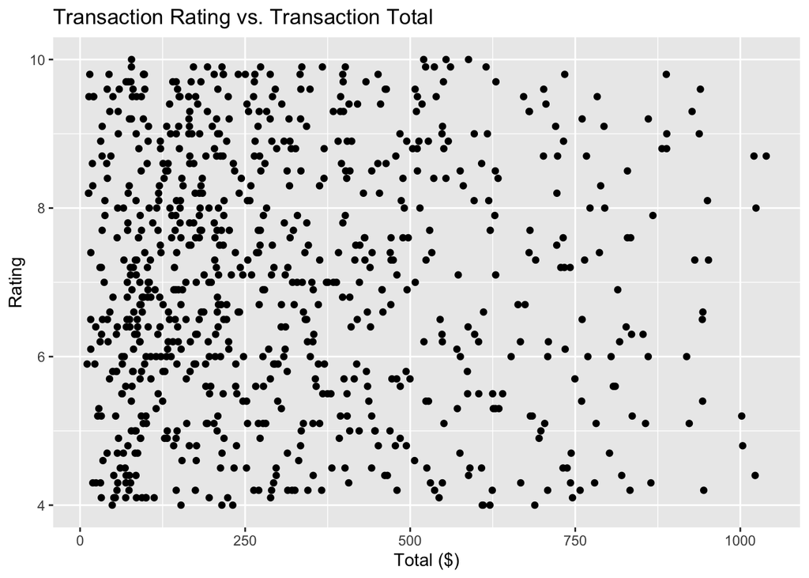

```r
train %>%
  ggplot(aes(x = total, y = rating)) +
  geom_point() +
  labs(title = "Transaction Rating vs. Transaction Total",
       x = "Total ($)",
       y = "Rating")
```

Well, this is a great example of how most real life data is not going to be perfectly linear. This data certainly shows no linear patter; in fact, this looks more like a random scatter with no pattern than anything. I wouldn’t say that we have satisfied this condition. It also doesn’t quite make sense to run a regression analysis with these variables as there does not appear to be a relationship at all between the two.

```r
cor(train$rating, train$total) %>%
  round(5)
```

```
## [1] -0.01661
```

As we can see, the correlation is very close to zero indicating that there is low evidence of a linear relationship between `rating` and `total`.

We can also check this with our errors. First, we need to calculate the errors for the training dataset (we previously found the errors for the testing dataset). Then we can plot the errors versus the predicted values.

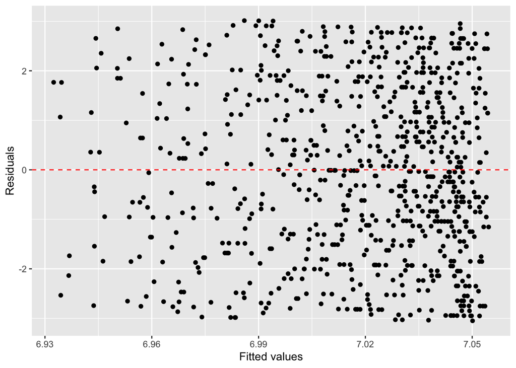

```r
train_aug <- augment(slr_mod_total, new_data = train)

ggplot(data = train_aug, aes(x = .pred, y = .resid)) +
  geom_point() +
  geom_hline(yintercept = 0, linetype = "dashed", color = "red") +
  xlab("Fitted values") +
  ylab("Residuals")
```

We are looking for a random scatter of points (and not a pattern). We do see a random scatter here which is a good sign!

### Normal Errors

We can make a histogram of the errors to check for the normality assumption.

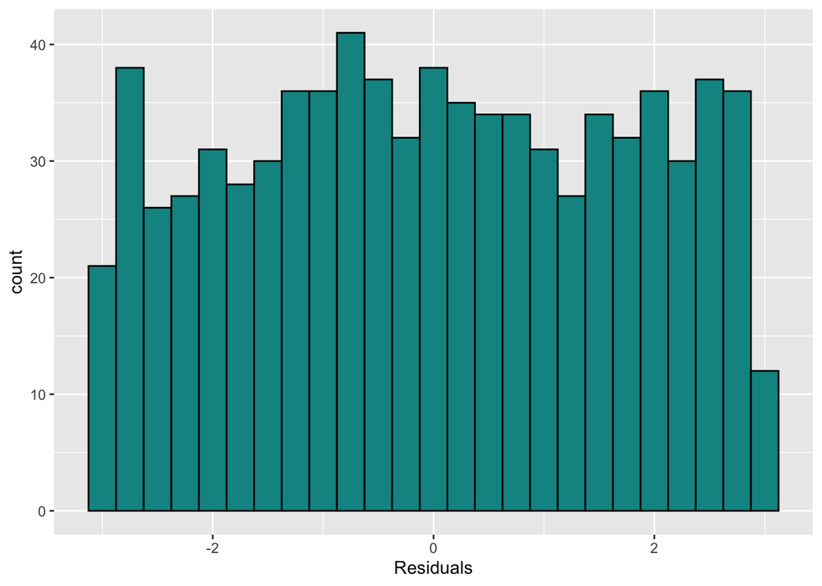

```r
ggplot(data = train_aug, aes(x = .resid)) +
  geom_histogram(binwidth = 0.25, fill = "#099392", color = "black") +
  xlab("Residuals")
```

## Wrap Up

All in all, simple linear regression was not a good model to choose for predicting `rating`. With only one variable, we don’t get a lot of information to help us predict `rating` accurately. My original prediction was not correct as both `unit_price` and `total` alone do not tell us much about `rating`.

# Multiple Linear Regression

Above, we weren’t able to predict `rating` with one variable alone. What if we could use multiple variables in regression model? Maybe then we can explain more variance in `rating`.

## Requirements

When can we use multiple linear regression (MLR)?

- The response variable (the variable we are predicting) must be continuous.
- The predictor variable (the variable we are using to predict) can be either continuous or categorical with any amount of levels.
- We only get one response variable but can have as many predictor variables as we wish.

We also still have to meet the regression assumptions:

- The relationship between the predictor variable and the response variables should be linear
- The errors of our predictions should be approximately normally distributed
- Our predictor variables should not be correlated with each other
- There should be a constant variability in our errors
- Our errors should be independent (we will not focus on this here)